# Analysis of real estate prices in Beijing using machine learning algorithms

# Introduction

## Beijing is the capital of the People's Republic of China. By the end of 2018, the permanent population of Beijing was 21.542 million, with a GDP of 303.2 billion yuan and a per capita GDP of 140,000 yuan. In the past two decades, the real estate market in mainland China has flourished and house prices have continued to rise. Beijing has always been the vane of China's real estate market, leading the Chinese real estate market to rise and fall again and again. Among them, the housing price sharply rose in 2009 and 2015, which were transmitted from first-tier cities such as Beijing to second- and third-tier cities, which eventually led to a nationwide real estate bull market. In particular, the real estate bull market in 2015 has exerted tremendous pressure on the Chinese people's psychology. When the real estate market is the hottest, the streets and alleys are talking about buying houses after the meal, and the real estate market is almost crazy. If you want to buy a house in Beijing, you may be wondering what factors affect the price of Beijing real estate, and which factor has the most significant impact on housing prices. With these questions, we will explore the second-hand housing market in Beijing.

# Data acquisition

## The data for this topic comes from kaggle，you can download the csv file from this url (https://www.kaggle.com/ruiqurm/lianjia). It includes URL, ID, Lng, Lat, CommunityID, TradeTime, DOM(days on market), Followers, Total price, Price, Square, Living Room, number of Drawing room, Kitchen and Bathroom, Building Type, Construction time, renovation condition, building structure, Ladder ratio( which is the proportion between number of residents on the same floor and number of elevator of ladder. It describes how many ladders a resident have on average), elevator, Property rights for five years（It's related to China restricted purchase of houses policy), Subway, District, Community average price.

```python
import pandas as pd
import numpy as np
import matplotlib.pyplot as plt
import seaborn as sns
import folium
from geopy.geocoders import Nominatim

pd.set_option('display.max_columns', None)
pd.set_option('display.max_rows', None)
np.set_printoptions(suppress=True)
pd.set_option('display.float_format', lambda x: '%.0f' % x)
```

```python
beijing=pd.read_csv('new.csv',encoding = "ISO-8859-1")
beijing.head()
print(beijing.shape)
```

```
(318851, 26)
```

```python
beijing.drop('url',axis=1,inplace=True)
beijing.dropna(axis=0,how='any',inplace=True)
print(beijing.shape)
```

```
(159376, 25)
```

```python
beijing.head()
```

|  | id | Lng | Lat | Cid | tradeTime | DOM | followers | totalPrice | price | square | livingRoom | drawingRoom | kitchen | bathRoom | floor | buildingType | constructionTime | renovationCondition | buildingStructure | ladderRatio | elevator | fiveYearsProperty | subway | district | communityAverage |
| --- | --- | --- | --- | --- | --- | --- | --- | --- | --- | --- | --- | --- | --- | --- | --- | --- | --- | --- | --- | --- | --- | --- | --- | --- | --- |
| 0 | 101085000000 | 116 | 40 | 1111030000000 | 2016/8/9 | 1464 | 106 | 415 | 31680 | 131 | 2 | 1 | 1 | 1 | ¸ß 26 | 1 | 2005 | 3 | 6 | 0 | 1 | 0 | 1 | 7 | 56021 |
| 1 | 101086000000 | 116 | 40 | 1111030000000 | 2016/7/28 | 903 | 126 | 575 | 43436 | 132 | 2 | 2 | 1 | 2 | ¸ß 22 | 1 | 2004 | 4 | 6 | 1 | 1 | 1 | 0 | 7 | 71539 |
| 2 | 101086000000 | 117 | 40 | 1111040000000 | 2016/12/11 | 1271 | 48 | 1030 | 52021 | 198 | 3 | 2 | 1 | 3 | ÖÐ 4 | 4 | 2005 | 3 | 6 | 0 | 1 | 0 | 0 | 7 | 48160 |
| 3 | 101086000000 | 116 | 40 | 1111040000000 | 2016/9/30 | 965 | 138 | 298 | 22202 | 134 | 3 | 1 | 1 | 1 | µ× 21 | 1 | 2008 | 1 | 6 | 0 | 1 | 0 | 0 | 6 | 51238 |
| 4 | 101087000000 | 116 | 40 | 1111030000000 | 2016/8/28 | 927 | 286 | 392 | 48396 | 81 | 2 | 1 | 1 | 1 | ÖÐ 6 | 4 | 1960 | 2 | 2 | 0 | 0 | 1 | 1 | 1 | 62588 |

```python
beijing=beijing.loc[beijing['Cid']==1111030000000]
beijing.head()
print(beijing.shape)
```

```
(150185, 25)
```

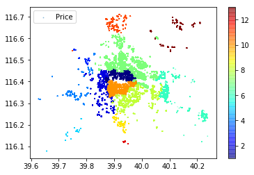

```python
fig = plt.scatter(x=beijing['Lat'], y=beijing['Lng'], alpha=0.4, \
    s=beijing['price']/100000, label='Price', \
    c=beijing['district'], cmap=plt.get_cmap('jet'))
plt.colorbar(fig)
plt.legend()
plt.show()
```

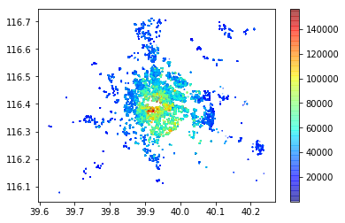

```python
fig = plt.scatter(x=beijing['Lat'], y=beijing['Lng'], alpha=0.4, \
    s=beijing['price']/100000,c=beijing['price'], cmap=plt.get_cmap('jet'))
plt.colorbar(fig)
plt.show()
```

```python
beijing['tradeTime']=pd.to_datetime(beijing['tradeTime']).dt.year
```

```python
beijing.head()
```

|  | id | Lng | Lat | Cid | tradeTime | DOM | followers | totalPrice | price | square | livingRoom | drawingRoom | kitchen | bathRoom | floor | buildingType | constructionTime | renovationCondition | buildingStructure | ladderRatio | elevator | fiveYearsProperty | subway | district | communityAverage |
| --- | --- | --- | --- | --- | --- | --- | --- | --- | --- | --- | --- | --- | --- | --- | --- | --- | --- | --- | --- | --- | --- | --- | --- | --- | --- |
| 0 | 101085000000 | 116 | 40 | 1111030000000 | 2016 | 1464 | 106 | 415 | 31680 | 131 | 2 | 1 | 1 | 1 | ¸ß 26 | 1 | 2005 | 3 | 6 | 0 | 1 | 0 | 1 | 7 | 56021 |
| 1 | 101086000000 | 116 | 40 | 1111030000000 | 2016 | 903 | 126 | 575 | 43436 | 132 | 2 | 2 | 1 | 2 | ¸ß 22 | 1 | 2004 | 4 | 6 | 1 | 1 | 1 | 0 | 7 | 71539 |
| 4 | 101087000000 | 116 | 40 | 1111030000000 | 2016 | 927 | 286 | 392 | 48396 | 81 | 2 | 1 | 1 | 1 | ÖÐ 6 | 4 | 1960 | 2 | 2 | 0 | 0 | 1 | 1 | 1 | 62588 |
| 5 | 101087000000 | 116 | 40 | 1111030000000 | 2016 | 861 | 57 | 276 | 52000 | 53 | 1 | 0 | 1 | 1 | ÖÐ 8 | 4 | 2005 | 3 | 6 | 0 | 1 | 1 | 0 | 7 | 67738 |
| 6 | 101087000000 | 116 | 40 | 1111030000000 | 2016 | 851 | 167 | 275 | 37672 | 73 | 2 | 1 | 1 | 1 | ¸ß 6 | 4 | 1997 | 4 | 2 | 0 | 0 | 0 | 0 | 7 | 50112 |

```python
beijing_1=beijing[beijing.tradeTime==2016]
beijing_1.shape
```

```
(62779, 25)
```

```python
result=beijing_1.sample(n=500,random_state=1,axis=0)#.head(500)
result.reset_index(inplace=True)
result.head()
```

|  | index | id | Lng | Lat | Cid | tradeTime | DOM | followers | totalPrice | price | square | livingRoom | drawingRoom | kitchen | bathRoom | floor | buildingType | constructionTime | renovationCondition | buildingStructure | ladderRatio | elevator | fiveYearsProperty | subway | district | communityAverage |
| --- | --- | --- | --- | --- | --- | --- | --- | --- | --- | --- | --- | --- | --- | --- | --- | --- | --- | --- | --- | --- | --- | --- | --- | --- | --- | --- |
| 0 | 20135 | 101100000000 | 116 | 40 | 1111030000000 | 2016 | 4 | 0 | 231 | 23852 | 97 | 2 | 1 | 1 | 1 | ¶¥ 6 | 4 | 2002 | 1 | 2 | 0 | 0 | 0 | 0 | 2 | 43463 |
| 1 | 276136 | BJSJ91387866 | 116 | 40 | 1111030000000 | 2016 | 1 | 15 | 158 | 34802 | 45 | 1 | 1 | 1 | 1 | ÖÐ 5 | 4 | 1993 | 4 | 2 | 0 | 0 | 0 | 0 | 9 | 48951 |
| 2 | 206356 | BJDC91667125 | 116 | 40 | 1111030000000 | 2016 | 1 | 12 | 600 | 92550 | 65 | 2 | 1 | 1 | 1 | ÖÐ 7 | 4 | 2002 | 1 | 6 | 0 | 0 | 1 | 1 | 1 | 104629 |
| 3 | 184764 | BJCY91299409 | 116 | 40 | 1111030000000 | 2016 | 1 | 4 | 159 | 26918 | 59 | 1 | 1 | 1 | 1 | µÍ 13 | 3 | 2011 | 3 | 6 | 0 | 1 | 0 | 1 | 7 | 52870 |
| 4 | 206739 | BJDC91845134 | 116 | 40 | 1111030000000 | 2016 | 1 | 15 | 415 | 45776 | 91 | 2 | 1 | 1 | 1 | ÖÐ 13 | 3 | 2005 | 3 | 6 | 0 | 1 | 1 | 1 | 1 | 65928 |

```python
result.shape
```

```
(500, 26)
```

```python
!pip install geopy
```

```
You are using pip version 19.0.2, however version 19.2.3 is available.
```

```python
address = 'Beijing City'

geolocator = Nominatim(user_agent="ny_explorer",timeout=10)
```

```python
location = geolocator.geocode(address)
latitude = location.latitude
longitude = location.longitude
```

```python
map_beijing = folium.Map(location=[latitude, longitude],tiles='stamentoner', zoom_start=10)
map_beijing
```

[interactive chart not shown]

```python
# add markers to map
for lat, lng, price in zip(result['Lat'], result['Lng'], result['price']):
    label = '{}'.format(price)
    label = folium.Popup(label, parse_html=True)
    folium.CircleMarker(
        [lat, lng],
        radius=3,
        popup=label,
        color='blue',
        fill=True,
        fill_color='#3186cc',
        fill_opacity=0.7,
        parse_html=False).add_to(map_beijing)

map_beijing
```

[interactive chart not shown]

```python
result.head()
```

|  | index | id | Lng | Lat | Cid | tradeTime | DOM | followers | totalPrice | price | square | livingRoom | drawingRoom | kitchen | bathRoom | floor | buildingType | constructionTime | renovationCondition | buildingStructure | ladderRatio | elevator | fiveYearsProperty | subway | district | communityAverage |
| --- | --- | --- | --- | --- | --- | --- | --- | --- | --- | --- | --- | --- | --- | --- | --- | --- | --- | --- | --- | --- | --- | --- | --- | --- | --- | --- |
| 0 | 20135 | 101100000000 | 116 | 40 | 1111030000000 | 2016 | 4 | 0 | 231 | 23852 | 97 | 2 | 1 | 1 | 1 | ¶¥ 6 | 4 | 2002 | 1 | 2 | 0 | 0 | 0 | 0 | 2 | 43463 |
| 1 | 276136 | BJSJ91387866 | 116 | 40 | 1111030000000 | 2016 | 1 | 15 | 158 | 34802 | 45 | 1 | 1 | 1 | 1 | ÖÐ 5 | 4 | 1993 | 4 | 2 | 0 | 0 | 0 | 0 | 9 | 48951 |
| 2 | 206356 | BJDC91667125 | 116 | 40 | 1111030000000 | 2016 | 1 | 12 | 600 | 92550 | 65 | 2 | 1 | 1 | 1 | ÖÐ 7 | 4 | 2002 | 1 | 6 | 0 | 0 | 1 | 1 | 1 | 104629 |
| 3 | 184764 | BJCY91299409 | 116 | 40 | 1111030000000 | 2016 | 1 | 4 | 159 | 26918 | 59 | 1 | 1 | 1 | 1 | µÍ 13 | 3 | 2011 | 3 | 6 | 0 | 1 | 0 | 1 | 7 | 52870 |
| 4 | 206739 | BJDC91845134 | 116 | 40 | 1111030000000 | 2016 | 1 | 15 | 415 | 45776 | 91 | 2 | 1 | 1 | 1 | ÖÐ 13 | 3 | 2005 | 3 | 6 | 0 | 1 | 1 | 1 | 1 | 65928 |

```python
result.info()
```

```
<class 'pandas.core.frame.DataFrame'>
RangeIndex: 500 entries, 0 to 499
Data columns (total 26 columns):
index                  500 non-null int64
id                     500 non-null object
Lng                    500 non-null float64
Lat                    500 non-null float64
Cid                    500 non-null float64
tradeTime              500 non-null int64
DOM                    500 non-null float64
followers              500 non-null int64
totalPrice             500 non-null float64
price                  500 non-null int64
square                 500 non-null float64
livingRoom             500 non-null object
drawingRoom            500 non-null object
kitchen                500 non-null int64
bathRoom               500 non-null object
floor                  500 non-null object
buildingType           500 non-null float64
constructionTime       500 non-null object
renovationCondition    500 non-null int64
buildingStructure      500 non-null int64
ladderRatio            500 non-null float64
elevator               500 non-null float64
fiveYearsProperty      500 non-null float64
subway                 500 non-null float64
district               500 non-null int64
communityAverage       500 non-null float64
dtypes: float64(12), int64(8), object(6)
memory usage: 101.6+ KB
```

```python
result.columns
```

```
Index(['index', 'id', 'Lng', 'Lat', 'Cid', 'tradeTime', 'DOM', 'followers',
       'totalPrice', 'price', 'square', 'livingRoom', 'drawingRoom', 'kitchen',
       'bathRoom', 'floor', 'buildingType', 'constructionTime',
       'renovationCondition', 'buildingStructure', 'ladderRatio', 'elevator',
       'fiveYearsProperty', 'subway', 'district', 'communityAverage'],
      dtype='object')
```

```python
house=result[['price', 'DOM', 'followers', 'square','drawingRoom','floor', 'kitchen', 'bathRoom',
        'buildingType', 'constructionTime', 'renovationCondition',
       'buildingStructure', 'ladderRatio', 'elevator', 'fiveYearsProperty',
       'subway', 'district']]
```

```python
# house['floor']=house.floor.str.split(' ',expand=True).iloc[:,1]
```

```python
# house=house.convert_objects(convert_numeric=True)
```

```python
house.info()
```

```
<class 'pandas.core.frame.DataFrame'>
RangeIndex: 500 entries, 0 to 499
Data columns (total 17 columns):
price                  500 non-null int64
DOM                    500 non-null float64
followers              500 non-null int64
square                 500 non-null float64
drawingRoom            500 non-null object
floor                  500 non-null object
kitchen                500 non-null int64
bathRoom               500 non-null object
buildingType           500 non-null float64
constructionTime       500 non-null object
renovationCondition    500 non-null int64
buildingStructure      500 non-null int64
ladderRatio            500 non-null float64
elevator               500 non-null float64
fiveYearsProperty      500 non-null float64
subway                 500 non-null float64
district               500 non-null int64
dtypes: float64(7), int64(6), object(4)
memory usage: 66.5+ KB
```

```python
house=house.select_dtypes(include=['float64', 'int64'])
```

```python
np.set_printoptions(suppress=True)
pd.set_option('display.float_format', lambda x: '%.4f' % x)
```

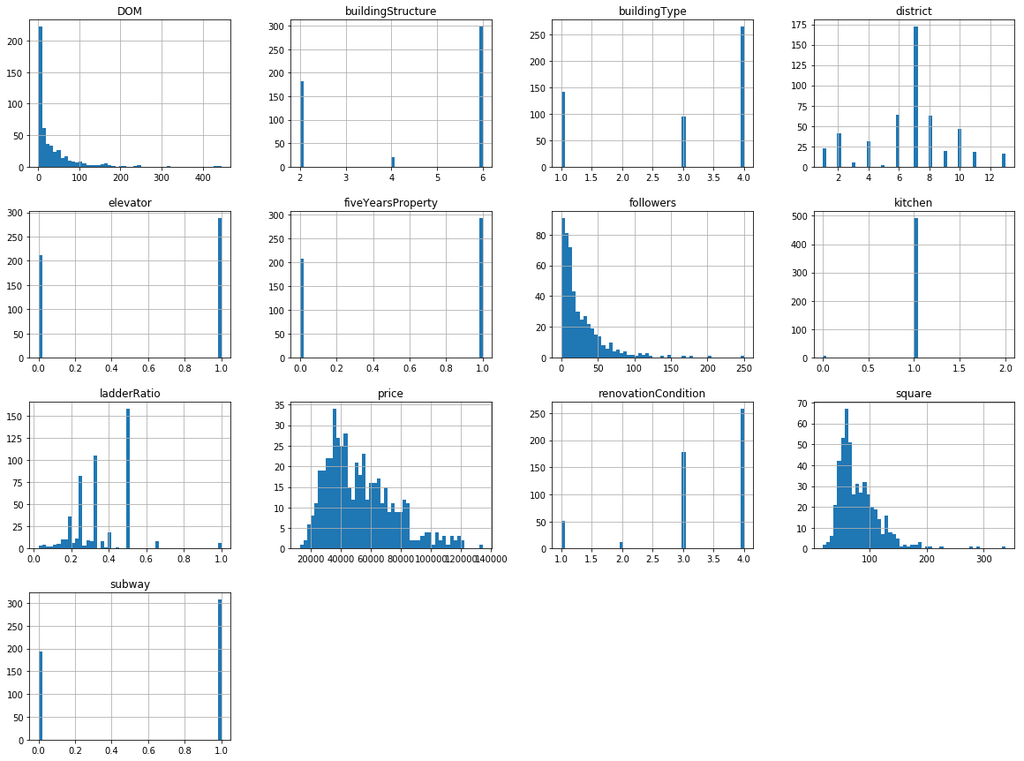

```python
house.hist(bins=50, figsize=(20,15))
plt.show()
```

```python
house.describe(include='all')
```

|  | price | DOM | followers | square | kitchen | buildingType | renovationCondition | buildingStructure | ladderRatio | elevator | fiveYearsProperty | subway | district |
| --- | --- | --- | --- | --- | --- | --- | --- | --- | --- | --- | --- | --- | --- |
| count | 500.0000 | 500.0000 | 500.0000 | 500.0000 | 500.0000 | 500.0000 | 500.0000 | 500.0000 | 500.0000 | 500.0000 | 500.0000 | 500.0000 | 500.0000 |
| mean | 53020.1020 | 33.2220 | 26.1200 | 80.9851 | 0.9900 | 2.9640 | 3.2880 | 4.4640 | 0.3569 | 0.5780 | 0.5860 | 0.6140 | 6.7660 |
| std | 22738.4451 | 51.4520 | 30.5324 | 36.9156 | 0.1180 | 1.2876 | 0.9310 | 1.9058 | 0.1490 | 0.4944 | 0.4930 | 0.4873 | 2.7133 |
| min | 12787.0000 | 1.0000 | 0.0000 | 18.0000 | 0.0000 | 1.0000 | 1.0000 | 2.0000 | 0.0260 | 0.0000 | 0.0000 | 0.0000 | 1.0000 |
| 25% | 35498.0000 | 1.0000 | 7.0000 | 56.2000 | 1.0000 | 1.0000 | 3.0000 | 2.0000 | 0.2500 | 0.0000 | 0.0000 | 0.0000 | 6.0000 |
| 50% | 49177.0000 | 14.0000 | 15.0000 | 71.2450 | 1.0000 | 4.0000 | 4.0000 | 6.0000 | 0.3330 | 1.0000 | 1.0000 | 1.0000 | 7.0000 |
| 75% | 66353.7500 | 45.0000 | 35.0000 | 97.9100 | 1.0000 | 4.0000 | 4.0000 | 6.0000 | 0.5000 | 1.0000 | 1.0000 | 1.0000 | 8.0000 |
| max | 134371.0000 | 445.0000 | 250.0000 | 338.0500 | 2.0000 | 4.0000 | 4.0000 | 6.0000 | 1.0000 | 1.0000 | 1.0000 | 1.0000 | 13.0000 |

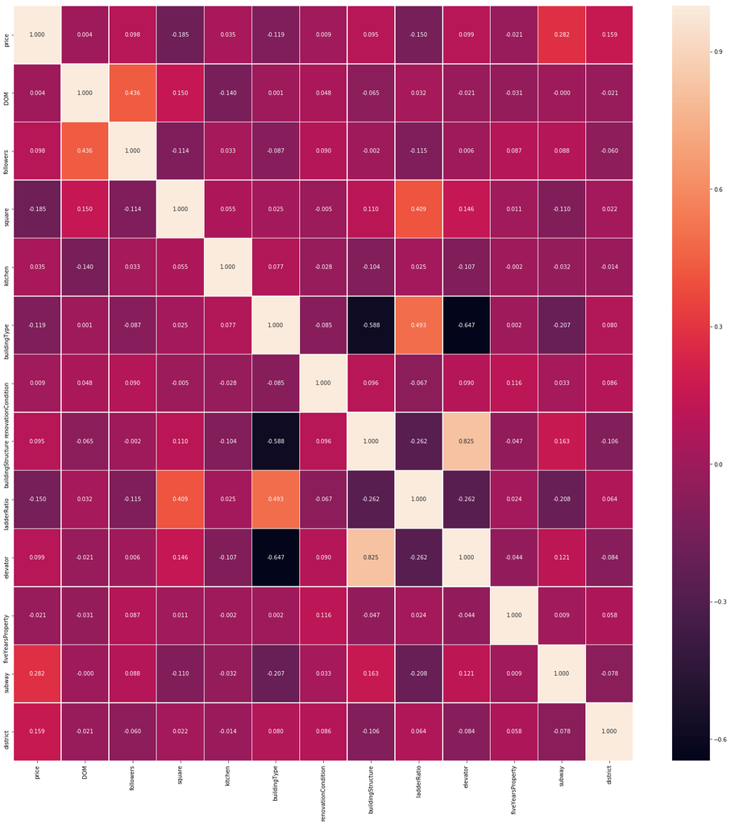

```python
f,ax = plt.subplots(figsize=(25, 25))
sns.heatmap(house.corr(), annot = True, linewidth = .5, fmt = ".3f",ax = ax)
plt.show()
```

```python
house.corr()
```

|  | price | DOM | followers | square | kitchen | buildingType | renovationCondition | buildingStructure | ladderRatio | elevator | fiveYearsProperty | subway | district |
| --- | --- | --- | --- | --- | --- | --- | --- | --- | --- | --- | --- | --- | --- |
| price | 1.0000 | 0.0038 | 0.0977 | -0.1850 | 0.0350 | -0.1195 | 0.0095 | 0.0947 | -0.1505 | 0.0991 | -0.0208 | 0.2821 | 0.1594 |
| DOM | 0.0038 | 1.0000 | 0.4358 | 0.1504 | -0.1402 | 0.0010 | 0.0484 | -0.0647 | 0.0319 | -0.0214 | -0.0306 | -0.0003 | -0.0215 |
| followers | 0.0977 | 0.4358 | 1.0000 | -0.1141 | 0.0331 | -0.0867 | 0.0897 | -0.0023 | -0.1154 | 0.0058 | 0.0869 | 0.0881 | -0.0595 |
| square | -0.1850 | 0.1504 | -0.1141 | 1.0000 | 0.0547 | 0.0245 | -0.0049 | 0.1097 | 0.4093 | 0.1459 | 0.0112 | -0.1100 | 0.0224 |
| kitchen | 0.0350 | -0.1402 | 0.0331 | 0.0547 | 1.0000 | 0.0768 | -0.0285 | -0.1041 | 0.0254 | -0.1068 | -0.0024 | -0.0324 | -0.0136 |
| buildingType | -0.1195 | 0.0010 | -0.0867 | 0.0245 | 0.0768 | 1.0000 | -0.0849 | -0.5877 | 0.4933 | -0.6472 | 0.0017 | -0.2074 | 0.0796 |
| renovationCondition | 0.0095 | 0.0484 | 0.0897 | -0.0049 | -0.0285 | -0.0849 | 1.0000 | 0.0962 | -0.0665 | 0.0904 | 0.1162 | 0.0335 | 0.0862 |
| buildingStructure | 0.0947 | -0.0647 | -0.0023 | 0.1097 | -0.1041 | -0.5877 | 0.0962 | 1.0000 | -0.2621 | 0.8251 | -0.0468 | 0.1630 | -0.1061 |
| ladderRatio | -0.1505 | 0.0319 | -0.1154 | 0.4093 | 0.0254 | 0.4933 | -0.0665 | -0.2621 | 1.0000 | -0.2624 | 0.0238 | -0.2076 | 0.0638 |
| elevator | 0.0991 | -0.0214 | 0.0058 | 0.1459 | -0.1068 | -0.6472 | 0.0904 | 0.8251 | -0.2624 | 1.0000 | -0.0440 | 0.1211 | -0.0842 |
| fiveYearsProperty | -0.0208 | -0.0306 | 0.0869 | 0.0112 | -0.0024 | 0.0017 | 0.1162 | -0.0468 | 0.0238 | -0.0440 | 1.0000 | 0.0092 | 0.0578 |
| subway | 0.2821 | -0.0003 | 0.0881 | -0.1100 | -0.0324 | -0.2074 | 0.0335 | 0.1630 | -0.2076 | 0.1211 | 0.0092 | 1.0000 | -0.0775 |
| district | 0.1594 | -0.0215 | -0.0595 | 0.0224 | -0.0136 | 0.0796 | 0.0862 | -0.1061 | 0.0638 | -0.0842 | 0.0578 | -0.0775 | 1.0000 |

```python
from sklearn.model_selection import train_test_split

X, y = house.iloc[:, 1:].values, house.iloc[:, 0].values

X_train, X_test, y_train, y_test =train_test_split(X, y,
                     test_size=0.25,
                     random_state=0)
```

```python
# from sklearn.preprocessing import StandardScaler

# stdsc = StandardScaler()
# X_train_std = stdsc.fit_transform(X_train)
# X_test_std = stdsc.fit_transform(X_test)
```

```
 1) district                       0.593322
 2) square                         0.105718
 3) DOM                            0.098869
 4) followers                      0.062617
 5) ladderRatio                    0.045412
 6) subway                         0.029471
 7) renovationCondition            0.017674
 8) fiveYearsProperty              0.014734
 9) buildingType                   0.011582
10) elevator                       0.010396
11) buildingStructure              0.009402
12) kitchen                        0.000804
```

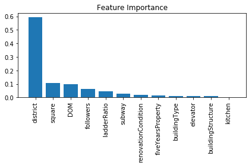

```python
from sklearn.ensemble import RandomForestRegressor

feat_labels = house.columns[1:]

forest = RandomForestRegressor(n_estimators=1000,
                               criterion='mse',
                               random_state=1,
                               n_jobs=-1)

forest.fit(X_train, y_train)
importances = forest.feature_importances_

indices = np.argsort(importances)[::-1]

for f in range(X_train_std.shape[1]):
    print("%2d) %-*s %f" % (f + 1, 30,
                            feat_labels[indices[f]],
                            importances[indices[f]]))

plt.title('Feature Importance')
plt.bar(range(X_train_std.shape[1]),
        importances[indices],
        align='center')

plt.xticks(range(X_train_std.shape[1]),
           feat_labels[indices], rotation=90)
plt.xlim([-1, X_train_std.shape[1]])
plt.tight_layout()
plt.show()
```

```python
y_train_pred = forest.predict(X_train)
y_test_pred = forest.predict(X_test)
```

```python
from sklearn.metrics import r2_score
from sklearn.metrics import mean_squared_error

print('MSE train: %.3f, test: %.3f' % (
        mean_squared_error(y_train, y_train_pred),
        mean_squared_error(y_test, y_test_pred)))
print('R^2 train: %.3f, test: %.3f' % (
        r2_score(y_train, y_train_pred),
        r2_score(y_test, y_test_pred)))
```

```
MSE train: 26446674.309, test: 205929032.236
R^2 train: 0.947, test: 0.629
```

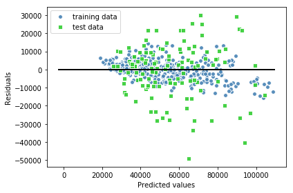

```python
plt.scatter(y_train_pred,
            y_train_pred - y_train,
            c='steelblue',
            edgecolor='white',
            marker='o',
            s=35,
            alpha=0.9,
            label='training data')
plt.scatter(y_test_pred,
            y_test_pred - y_test,
            c='limegreen',
            edgecolor='white',
            marker='s',
            s=35,
            alpha=0.9,
            label='test data')

plt.xlabel('Predicted values')
plt.ylabel('Residuals')
plt.legend(loc='upper left')
plt.hlines(y=0, xmin=-3000, xmax=110000, lw=2, color='black')
# plt.xlim([-10, 50])
plt.tight_layout()

# plt.savefig('images/10_14.png', dpi=300)
plt.show()
```